# Latest optimization results

24/09, 2024

## Brief recap

- Transform 14% of Denmark from agriculture to nature
- Maximize biodiversity and contiguity of nature areas
- At least 250,000 hectares of new forest promised
- At least 140,000 hectares of wet areas

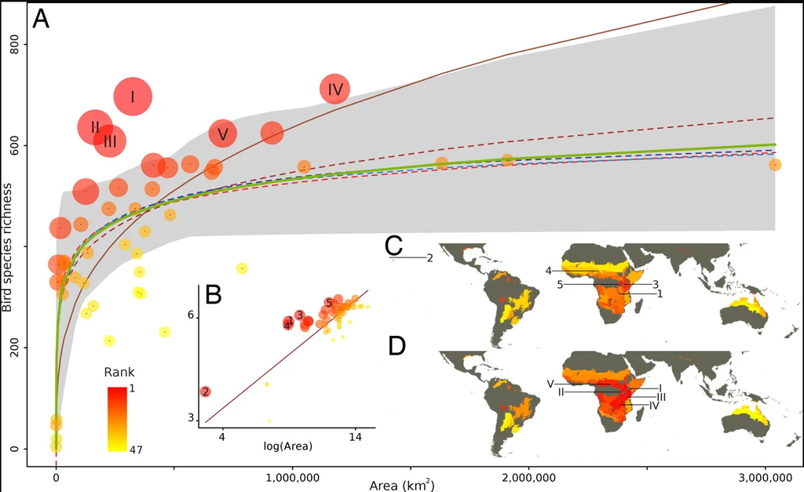

## Maximize biodiversity

- Species Richness, Phylogenetic diversity, Rarity

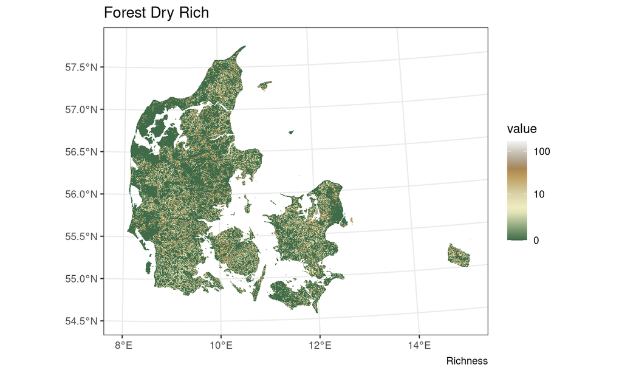

- One estimate per habitat type

## Summary of solution for all of Denmark

| Landuse | current | solution | added | added_proportion |
| --- | --- | --- | --- | --- |
| FDR_N | 41.72 | 1605.80 | 1564.08 | 3748.99 |
| ODR_N | 163.12 | 1491.76 | 1328.64 | 814.52 |
| ODP_N | 951.92 | 1814.84 | 862.92 | 90.65 |
| OWR_N | 1462.60 | 1943.20 | 480.60 | 32.86 |
| FWR_N | 16.24 | 398.40 | 382.16 | 2353.20 |
| FWP_N | 26.04 | 325.76 | 299.72 | 1151.00 |
| FDP_N | 489.52 | 788.60 | 299.08 | 61.10 |
| OWP_N | 90.20 | 377.40 | 287.20 | 318.40 |
| Ag | 33215.24 | 27710.84 | -5504.40 | -16.57 |

## All of Denmark

## Most added nature

## Areas with the most added nature

Top 6 communes on proportional change

| Commune | Current | Solution | Prop_Change |
| --- | --- | --- | --- |
| Bornholm | 36.32 | 185.20 | 409.91 |
| Assens | 14.36 | 133.68 | 830.92 |
| Kolding | 20.04 | 99.68 | 397.41 |
| Favrskov | 14.84 | 87.72 | 491.11 |
| Lejre | 8.44 | 82.80 | 881.04 |
| Århus | 11.68 | 78.08 | 568.49 |

## Example 1

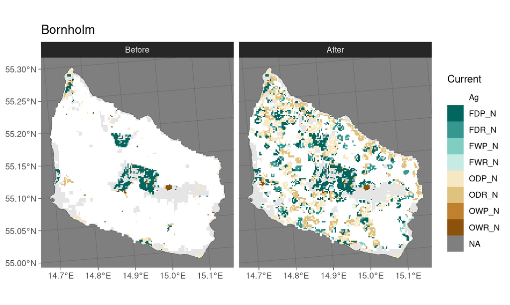

## Example 2

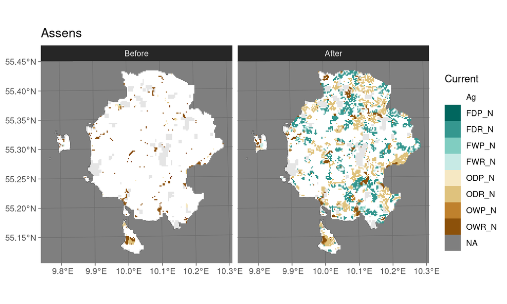

## Example 3

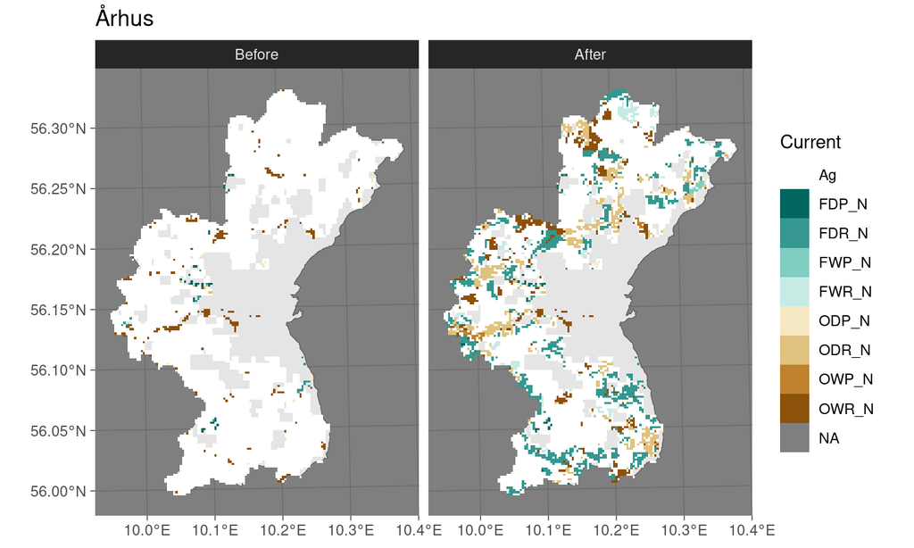

## Most added Open

## Most added Open

Top 6 communes on proportional change open nature

| Commune | Current | Solution | Prop_Change |
| --- | --- | --- | --- |
| Bornholm | 327 | 2473 | 656.27 |
| Assens | 355 | 1585 | 346.48 |
| Lejre | 167 | 1375 | 723.35 |
| Horsens | 526 | 1345 | 155.70 |
| Odsherred | 354 | 1248 | 252.54 |
| Holbæk | 404 | 1073 | 165.59 |

- The selection process first ranks the top 20 communes by proportional change in open nature
- From those, top 6 based on the largest total area of newly added nature.

## Example 1

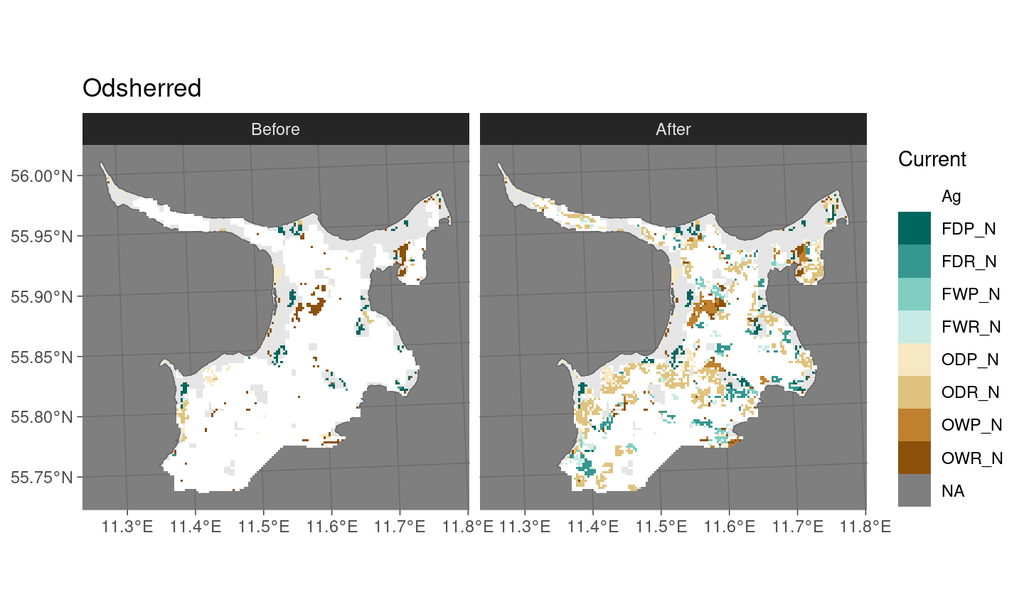

## Example 2

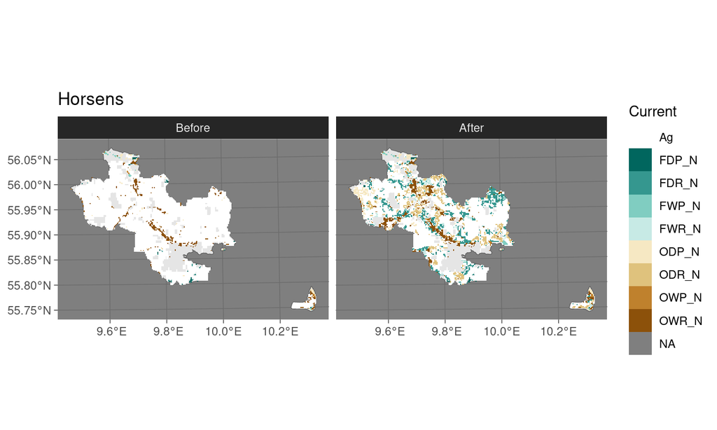

## Things to add

## New elements

Will have

- Carbon
- Private vs State

Nice to have later on

- Soil
- Restore natural areas

## Questions

## Equations

## Overall

\[\color{Red}{\text{Biodiversity} = \sum_{l}^L \sum_{c}^C \text{LD}_{l,c} \times \frac{\text{S}_{l,c} + \text{PD}_{l,c} + \text{R}_{l,c}}{3} \times \text{CC}_{c}}\]

\[\color{blue}{\text{Contiguity}_\text{New} =\text{Contiguity}[l,i,j] \times \text{CanChange}[i] \times \text{CanChange}[j]\times \text{LD}_{l,j}}\]